# Kyle Hostetter's **Used Cars Price Prediction**

### Categorical Univariate Countplots

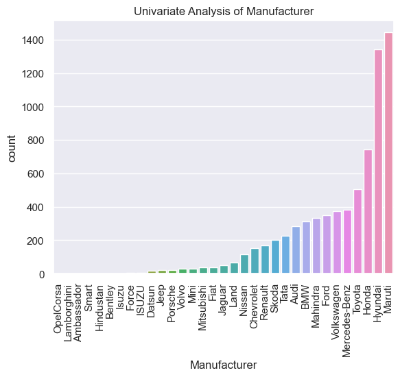

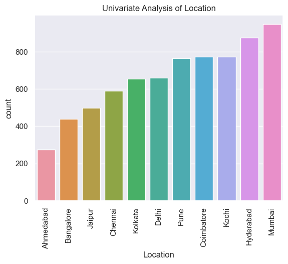

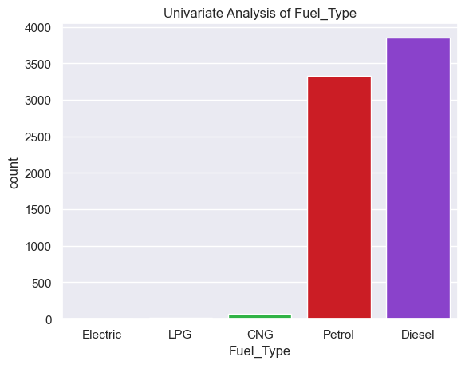

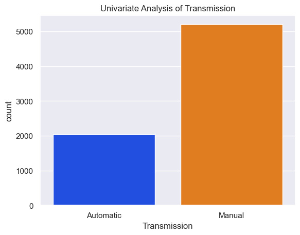

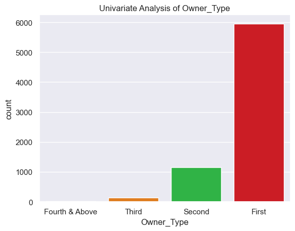

```python
# Categorical Univariate Analysis
for col in categorical_vars[1:]:

    # Set title for chart
    title = 'Univariate Analysis of ' + col

    # If there are too many variable rotate them to be vertical
    if col =='Manufacturer' or col == 'Location':
        orientation = 90    # Vertical orientation
    else:
        orientation = 0     # Horizontal orientation

    # Create countplot chart
    sns.countplot(data=df,                                                          # DataFrame
                  x=col,                                                            # Column Name
                  order=df[col].value_counts().sort_values(ascending=True).index)   # Set order from lowerest to highest count

    # Plot Chart
    plt.xticks(rotation=orientation)    # Select orientation
    plt.title(title)                    # Set title
    plt.show()                          # Plot Chart
```

**Countplot Observations**-

## **Bivariate Analysis**

**Questions:**

1. Plot a scatter plot for the log transformed values(if log_transformation done in previous steps)?
2. What can we infer form the correlation heatmap? Is there correlation between the dependent and independent variables?
3. Plot a box plot for target variable and categorical variable 'Location' and write your observations?

### Heatmap for Continuous Variable Correlations

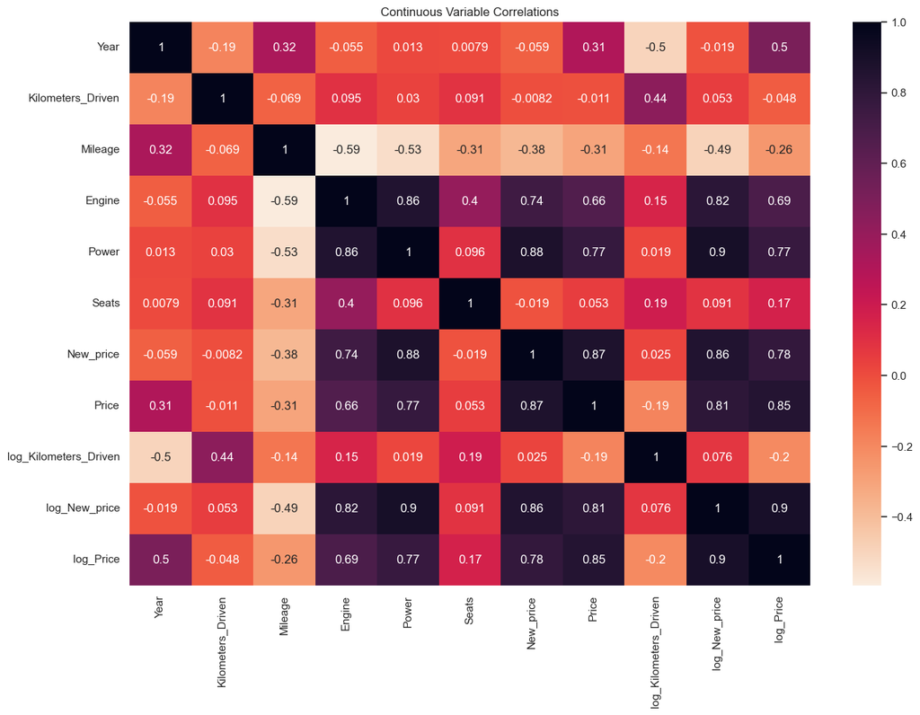

```python
'''First we need to see the correlation between all variables to see if there is any multicorrarity'''

# Set size of chart
plt.figure(figsize=(15,10))

sns.heatmap(df.corr(),          # Correlation chart
            annot=True,         # Add correlation value in each box
            cmap="rocket_r")    # Add color palette

# Set title of chart
plt.title('Continuous Variable Correlations')
```

**Heat Map Observations**-

### BoxPlots for Bivariate Categorical Analysis

```python
# For loop categorical variables for average price
for col in categorical_vars:
    print('Column Name:', col)                                                                            # Prints column name
    print('-'*50)                                                                                         # Header Line
    ordered_df = df.groupby(col,
                            as_index=False)['Price'].mean().sort_values(by='Price', ascending=False)      # Calculates average price of each categorical variable
    display(ordered_df)
```

```
Column Name: Name
--------------------------------------------------
```

|  | Name | Price |
| --- | --- | --- |
| 891 | Land Rover Range Rover 3.0 Diesel LWB Vogue | 160.000 |
| 868 | Lamborghini Gallardo Coupe | 120.000 |
| 845 | Jaguar F Type 5.0 V8 S | 100.000 |
| 134 | BMW 7 Series 740Li | 93.335 |
| 1462 | Mercedes-Benz SLK-Class 55 AMG | 90.000 |
| ... | ... | ... |
| 1996 | Volkswagen Vento 1.2 TSI Comfortline AT | NaN |
| 2003 | Volkswagen Vento 1.5 TDI Highline Plus | NaN |
| 2004 | Volkswagen Vento 1.5 TDI Highline Plus AT | NaN |
| 2008 | Volkswagen Vento 1.6 Trendline | NaN |
| 2028 | Volvo S60 D5 Kinetic | NaN |

2041 rows × 2 columns

```
Column Name: Manufacturer
--------------------------------------------------
```

|  | Manufacturer | Price |
| --- | --- | --- |
| 16 | Lamborghini | 120.000000 |
| 3 | Bentley | 59.000000 |
| 25 | Porsche | 48.348333 |
| 17 | Land | 39.259500 |
| 14 | Jaguar | 37.632250 |
| 21 | Mini | 26.896923 |
| 20 | Mercedes-Benz | 26.809874 |
| 1 | Audi | 25.537712 |
| 2 | BMW | 25.243146 |
| 13 | Isuzu | 20.000000 |
| 32 | Volvo | 18.802857 |
| 15 | Jeep | 18.718667 |
| 12 | ISUZU | 12.045000 |
| 30 | Toyota | 11.580024 |
| 22 | Mitsubishi | 11.058889 |
| 7 | Force | 9.333333 |
| 18 | Mahindra | 8.045919 |
| 27 | Skoda | 7.559075 |
| 8 | Ford | 6.889400 |
| 26 | Renault | 5.799034 |
| 10 | Honda | 5.411743 |
| 11 | Hyundai | 5.343433 |
| 31 | Volkswagen | 5.307270 |
| 23 | Nissan | 4.738352 |
| 19 | Maruti | 4.517267 |
| 29 | Tata | 3.562849 |
| 6 | Fiat | 3.269286 |
| 5 | Datsun | 3.049231 |
| 4 | Chevrolet | 3.044463 |
| 28 | Smart | 3.000000 |
| 0 | Ambassador | 1.350000 |
| 9 | Hindustan | NaN |
| 24 | OpelCorsa | NaN |

```
Column Name: Location
--------------------------------------------------
```

|  | Location | Price |
| --- | --- | --- |
| 3 | Coimbatore | 15.078223 |
| 1 | Bangalore | 13.328631 |
| 7 | Kochi | 11.179186 |
| 5 | Hyderabad | 9.776550 |
| 4 | Delhi | 9.707726 |
| 9 | Mumbai | 9.429329 |
| 0 | Ahmedabad | 8.457321 |
| 2 | Chennai | 7.753623 |
| 10 | Pune | 6.726254 |
| 6 | Jaipur | 5.809225 |
| 8 | Kolkata | 5.661215 |

```
Column Name: Fuel_Type
--------------------------------------------------
```

|  | Fuel_Type | Price |
| --- | --- | --- |
| 2 | Electric | 12.875000 |
| 1 | Diesel | 12.840605 |
| 4 | Petrol | 5.701100 |
| 0 | CNG | 3.516786 |
| 3 | LPG | 2.487000 |

```
Column Name: Transmission
--------------------------------------------------
```

|  | Transmission | Price |
| --- | --- | --- |
| 0 | Automatic | 19.843971 |
| 1 | Manual | 5.332703 |

```
Column Name: Owner_Type
--------------------------------------------------
```

|  | Owner_Type | Price |
| --- | --- | --- |
| 0 | First | 9.962445 |
| 2 | Second | 7.599886 |
| 3 | Third | 5.007257 |
| 1 | Fourth & Above | 3.280000 |

** Categorical Variable Vs. Price Oberservations**-

- Manufacturer - We can see that the any car that is Jaguar or above is an outlier. This would include Lamborghini, Bently, Porsche, Land, and Jaguar.
- Name - As we stated previously, the more exotic cars are going to be outliers. So they will need to be removed.
- Location - Coimbartore, Bangalore, and Kochi have the 3 highest car prices from any other countries in the dataset.
- Fuel_Type - We can see the diesel and electric cars are worth more than double of petrol.
- Transmission - Automatic is most popular as we saw earlier, but we also see that it is worth more as well, almost 4 times to be exact.
- Owner_type - As the amount of owners increases the average price of the car goes down. This was assumed to be true earlier.

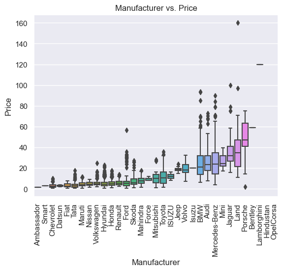

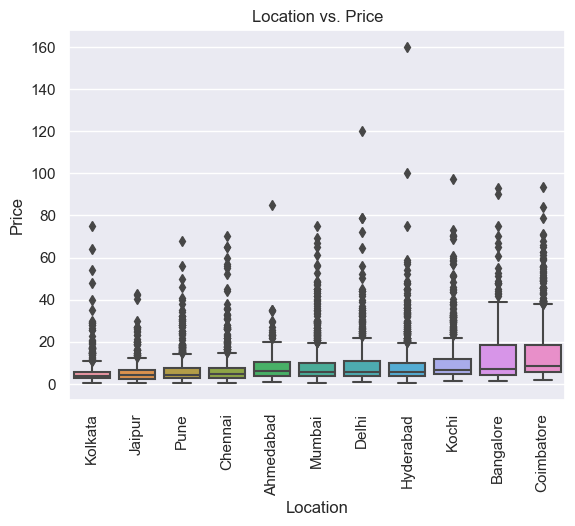

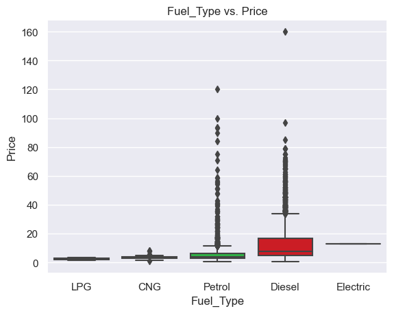

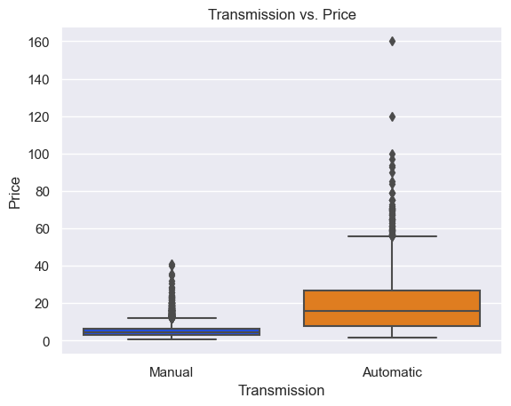

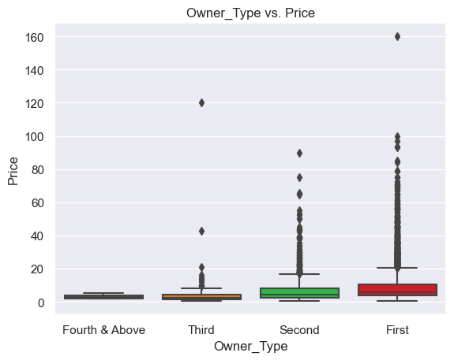

```python
# Create Box Plots for categorical variables
for col in categorical_vars[1:]:
    title = col + ' vs. Price'

    # If there are too many variable rotate them to be vertical
    if col =='Manufacturer' or col == 'Location':
        orientation = 90    # Vertical orientation
    else:
        orientation = 0     # Horizontal orientation

    # Create a boxplot for each variable
    sns.boxplot(data=df,                                                                    # DataFrame
                x=col,                                                                      # Categorical variable
                y='Price',                                                                  # This is the target variable
                order=df.groupby(col)['Price'].mean().sort_values(ascending=True).index)    # Sort values smallest to largest based on mean

    # Chart Parameters
    plt.xticks(rotation=orientation)    # Select orientation
    plt.title(title)                    # Set title
    plt.show()                          # Plot chart
```

**Boxplot Obersvations**-

- Manufacturer vs. Price - As you can see in this chart, the more exotic cars have the highest prices which make sense, but the european cars have a higher price average overall when compared to Asian or American cars.
- Location vs. Price - Coimbatore has the highest average price when compared to others, but also seems to have the highest range of values as well.
- Fuel_Type vs. Price - Electric cars have the highest price, but there are very few in this dataset. But we notice that diesel are worth the second most. And lastly we have the Petrol, which was the second most popular in this dataset, but does not have the higher price.
- Transmission vs. Price - We can see that the automatic transmissions are priced alot more than the manual transmissions here. This could be because it is easier to drive a automatic and therefore they have a higher demand.
- Owner_type vs. Price - We can still see that the largest priced cars go the first owner_type. We also see that there are some outliers, but we can just take those as higher prices for cars because they have only had one owner.

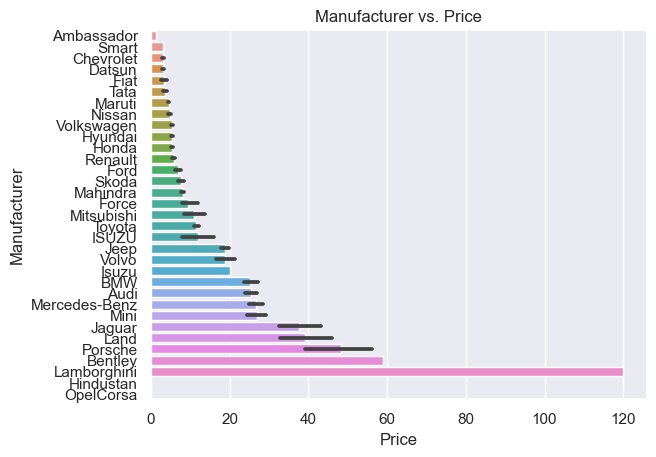

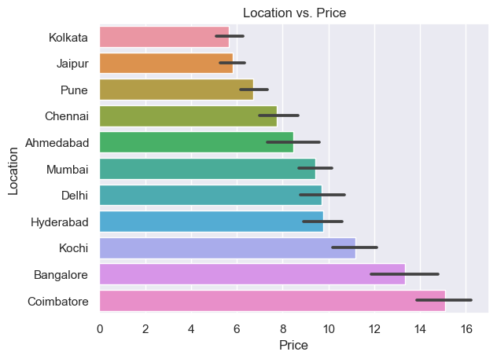

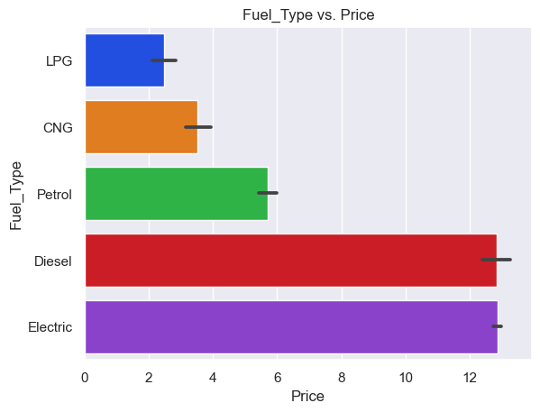

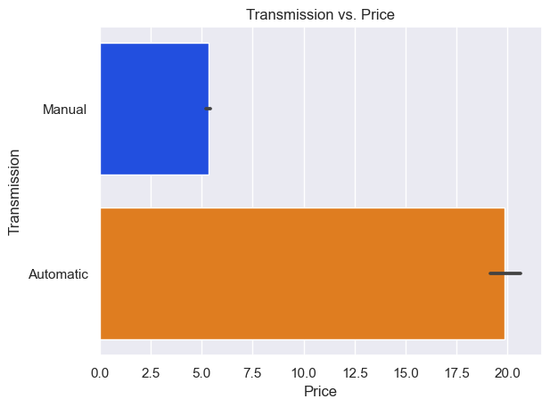

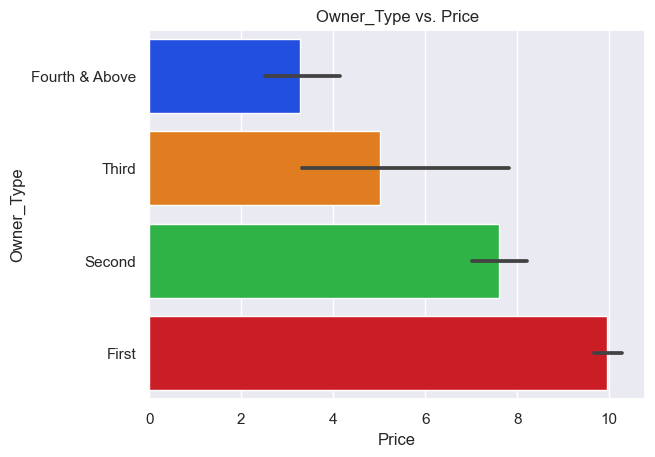

```python
# Create Box Plots for categorical variables
for col in categorical_vars[1:]:
    title = col + ' vs. Price'

    # Create a boxplot for each variable
    sns.barplot(data=df,                                                                    # DataFrame
                x=df['Price'],                                                                    # Categorical variable
                y=col,                                                                  # This is the target variable
                order=df.groupby(col)['Price'].mean().sort_values(ascending=True).index,
                orient="h")    # Sort values smallest to largest based on mean

    # Chart Parameters
    plt.xticks(rotation=orientation)    # Select orientation
    plt.title(title)                    # Set title
    plt.show()                          # Plot chart
    time.sleep(1)
    plt.savefig(col+'bar')
```

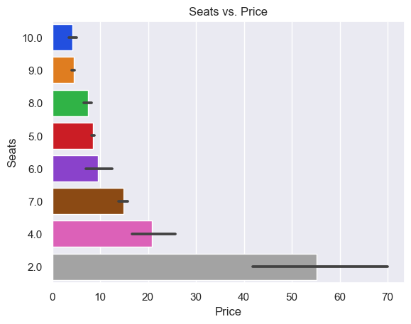

```python
title = 'Seats' + ' vs. Price'
# Create a boxplot for each variable
sns.barplot(data=df,                                                                    # DataFrame
            x='Price',                                                                    # Categorical variable
            y='Seats',                                                                  # This is the target variable
            order=df.groupby('Seats')['Price'].mean().sort_values(ascending=True).index,
            orient="h")    # Sort values smallest to largest based on mean

# Chart Parameters
plt.xticks(rotation=orientation)    # Select orientation
plt.title(title)                    # Set title
plt.show()                          # Plot chart
time.sleep(1)
```

### Scatter plots for Log Transformed Analysis

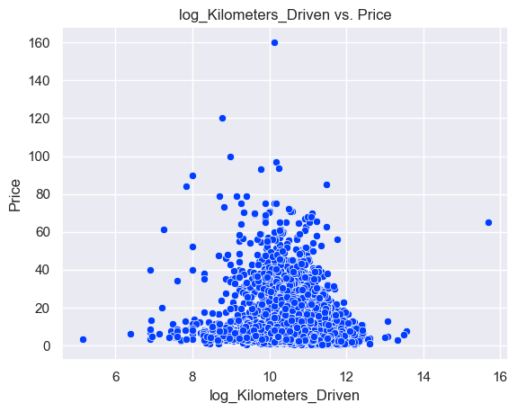

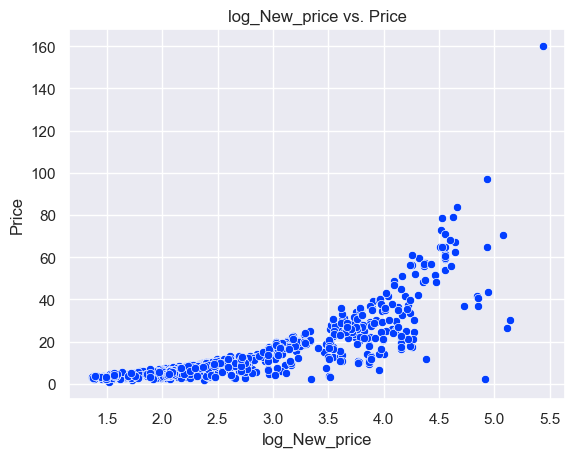

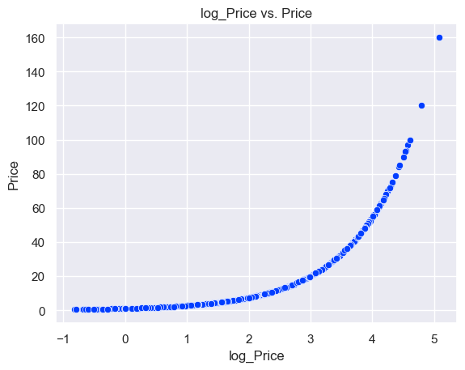

```python
# Create charts log Transformations
for col in log_column_names:
    title = col + ' vs. Price'  # Create title for chart

    # Create scatterplot for columns
    sns.scatterplot(data=df,    # DataFrame
                    x=col,      # Log transformed column
                    y='Price')  # Add Price to the y axis

    # Chart parameters
    plt.title(title)    # Tile for chart
    plt.show()          # Show chart
```

**ScatterPlot Observations**-

- log_Kilometers_Driven vs. Price - We can see that there is slight negative correlation. This would mean that the more miles that are on a car the less it will sell for.
- log_New_price vs. Price - You can see a positive correlation in a parabolic way. This would show how price increases so does the new price.
- log_Price vs. Price - This is going to show an almost perfect positive correlation, because this is just the log of the price data.

### **Feature Engineering**

**Think about it:** The `Name` column in the current format might not be very useful in our analysis. Since the name contains both the brand name and the model name of the vehicle, the column would have too many unique values to be useful in prediction. Can we extract that information from that column?

- **Hint:** With 2041 unique names, car names are not going to be great predictors of the price in our current data. But we can process this column to extract important information for example brand name.

```python
# Create copy of dataframe for further analysis and manipulation
df_copy = df.copy()
```

### **Missing value Treatment**

```python
# Percentage of values in each column that are NULL
print('NULL Values Based on Percentage')
print('-' * 50)
print((df.isnull().sum() / len(df)) * 100)

# Create list of null variables
continuous_null_vars = ['Mileage', 'Engine', 'Power']
dropping_null_vars = ['New_price', 'log_New_price']
categorical_null_vars = ['Seats']
target_null_vars = ['Price', 'log_Price']

# Fill Continuous NULL variables with Median
for col in continuous_null_vars:
    df_copy[col] = df_copy[col].fillna(df_copy[col].median())

# Fill Categorical Null Variables with Mean
for col in categorical_null_vars:
    df_copy[col] = df_copy[col].fillna(df_copy[col].mean())

# Drop columns with too large of NULL Percentage
df_copy = df_copy.drop(columns=dropping_null_vars)

# Create manufacturer DataFrame with Average Price
man_average_df= df.groupby('Manufacturer', as_index=False)['Price'].mean().sort_values(by='Price', ascending=False)

''' The original idea was to replace price with the average manufacturer's price for the Price column.'''
# # Replace NULL Price with a 0 for later use
# df_copy['Price'] = df_copy['Price'].fillna(0)

# # Loop through each row that was 0 and fill with the manufacturer average price for that car
# for i in range(0,len(df_copy)):
#     if df_copy['Price'][i] == 0:
#         df_copy['Price'][i] = man_average_df['Price'][man_average_df['Manufacturer'] == df_copy['Manufacturer'][i]]

# There are 2 car manufactures that do not have any prices for their cars. These are Hindustan & OpelCorsa.
df_copy = df_copy.dropna()

# Show Old DataFrame
print('\n\n Old DataFrame')
print('-' * 200)
display(df)

# Display new DataFrame
print('NULL Values for Cleaned DataFrame')
print('-' * 50)
print((df_copy.isnull().sum() / len(df_copy)) * 100)
print('\n\n Cleaned DataFrame')
print('-' * 200)
display(df_copy)
```

```
NULL Values Based on Percentage
--------------------------------------------------
Name                      0.000000
Location                  0.000000
Year                      0.000000
Kilometers_Driven         0.000000
Fuel_Type                 0.000000
Transmission              0.000000
Owner_Type                0.000000
Mileage                   0.027575
Engine                    0.634220
Power                     2.412795
Seats                     0.730732
New_price                86.129877
Price                    17.013650
Manufacturer              0.000000
log_Kilometers_Driven     0.000000
log_New_price            86.129877
log_Price                17.013650
dtype: float64


 Old DataFrame
--------------------------------------------------------------------------------------------------------------------------------------------------------------------------------------------------------
```

|  | Name | Location | Year | Kilometers_Driven | Fuel_Type | Transmission | Owner_Type | Mileage | Engine | Power | Seats | New_price | Price | Manufacturer | log_Kilometers_Driven | log_New_price | log_Price |
| --- | --- | --- | --- | --- | --- | --- | --- | --- | --- | --- | --- | --- | --- | --- | --- | --- | --- |
| 0 | Maruti Wagon R LXI CNG | Mumbai | 2010 | 72000 | CNG | Manual | First | 26.60 | 998.0 | 58.16 | 5.0 | NaN | 1.75 | Maruti | 11.184421 | NaN | 0.559616 |
| 1 | Hyundai Creta 1.6 CRDi SX Option | Pune | 2015 | 41000 | Diesel | Manual | First | 19.67 | 1582.0 | 126.20 | 5.0 | NaN | 12.50 | Hyundai | 10.621327 | NaN | 2.525729 |
| 2 | Honda Jazz V | Chennai | 2011 | 46000 | Petrol | Manual | First | 18.20 | 1199.0 | 88.70 | 5.0 | 8.61 | 4.50 | Honda | 10.736397 | 2.152924 | 1.504077 |
| 3 | Maruti Ertiga VDI | Chennai | 2012 | 87000 | Diesel | Manual | First | 20.77 | 1248.0 | 88.76 | 7.0 | NaN | 6.00 | Maruti | 11.373663 | NaN | 1.791759 |
| 4 | Audi A4 New 2.0 TDI Multitronic | Coimbatore | 2013 | 40670 | Diesel | Automatic | Second | 15.20 | 1968.0 | 140.80 | 5.0 | NaN | 17.74 | Audi | 10.613246 | NaN | 2.875822 |
| ... | ... | ... | ... | ... | ... | ... | ... | ... | ... | ... | ... | ... | ... | ... | ... | ... | ... |
| 7248 | Volkswagen Vento Diesel Trendline | Hyderabad | 2011 | 89411 | Diesel | Manual | First | 20.54 | 1598.0 | 103.60 | 5.0 | NaN | NaN | Volkswagen | 11.400999 | NaN | NaN |
| 7249 | Volkswagen Polo GT TSI | Mumbai | 2015 | 59000 | Petrol | Automatic | First | 17.21 | 1197.0 | 103.60 | 5.0 | NaN | NaN | Volkswagen | 10.985293 | NaN | NaN |
| 7250 | Nissan Micra Diesel XV | Kolkata | 2012 | 28000 | Diesel | Manual | First | 23.08 | 1461.0 | 63.10 | 5.0 | NaN | NaN | Nissan | 10.239960 | NaN | NaN |
| 7251 | Volkswagen Polo GT TSI | Pune | 2013 | 52262 | Petrol | Automatic | Third | 17.20 | 1197.0 | 103.60 | 5.0 | NaN | NaN | Volkswagen | 10.864025 | NaN | NaN |
| 7252 | Mercedes-Benz E-Class 2009-2013 E 220 CDI Avan... | Kochi | 2014 | 72443 | Diesel | Automatic | First | 10.00 | 2148.0 | 170.00 | 5.0 | NaN | NaN | Mercedes-Benz | 11.190555 | NaN | NaN |

7253 rows × 17 columns

```
NULL Values for Cleaned DataFrame
--------------------------------------------------
Name                     0.0
Location                 0.0
Year                     0.0
Kilometers_Driven        0.0
Fuel_Type                0.0
Transmission             0.0
Owner_Type               0.0
Mileage                  0.0
Engine                   0.0
Power                    0.0
Seats                    0.0
Price                    0.0
Manufacturer             0.0
log_Kilometers_Driven    0.0
log_Price                0.0
dtype: float64


 Cleaned DataFrame
--------------------------------------------------------------------------------------------------------------------------------------------------------------------------------------------------------
```

|  | Name | Location | Year | Kilometers_Driven | Fuel_Type | Transmission | Owner_Type | Mileage | Engine | Power | Seats | Price | Manufacturer | log_Kilometers_Driven | log_Price |
| --- | --- | --- | --- | --- | --- | --- | --- | --- | --- | --- | --- | --- | --- | --- | --- |
| 0 | Maruti Wagon R LXI CNG | Mumbai | 2010 | 72000 | CNG | Manual | First | 26.60 | 998.0 | 58.16 | 5.0 | 1.75 | Maruti | 11.184421 | 0.559616 |
| 1 | Hyundai Creta 1.6 CRDi SX Option | Pune | 2015 | 41000 | Diesel | Manual | First | 19.67 | 1582.0 | 126.20 | 5.0 | 12.50 | Hyundai | 10.621327 | 2.525729 |
| 2 | Honda Jazz V | Chennai | 2011 | 46000 | Petrol | Manual | First | 18.20 | 1199.0 | 88.70 | 5.0 | 4.50 | Honda | 10.736397 | 1.504077 |
| 3 | Maruti Ertiga VDI | Chennai | 2012 | 87000 | Diesel | Manual | First | 20.77 | 1248.0 | 88.76 | 7.0 | 6.00 | Maruti | 11.373663 | 1.791759 |
| 4 | Audi A4 New 2.0 TDI Multitronic | Coimbatore | 2013 | 40670 | Diesel | Automatic | Second | 15.20 | 1968.0 | 140.80 | 5.0 | 17.74 | Audi | 10.613246 | 2.875822 |
| ... | ... | ... | ... | ... | ... | ... | ... | ... | ... | ... | ... | ... | ... | ... | ... |
| 6014 | Maruti Swift VDI | Delhi | 2014 | 27365 | Diesel | Manual | First | 28.40 | 1248.0 | 74.00 | 5.0 | 4.75 | Maruti | 10.217020 | 1.558145 |
| 6015 | Hyundai Xcent 1.1 CRDi S | Jaipur | 2015 | 100000 | Diesel | Manual | First | 24.40 | 1120.0 | 71.00 | 5.0 | 4.00 | Hyundai | 11.512925 | 1.386294 |
| 6016 | Mahindra Xylo D4 BSIV | Jaipur | 2012 | 55000 | Diesel | Manual | Second | 14.00 | 2498.0 | 112.00 | 8.0 | 2.90 | Mahindra | 10.915088 | 1.064711 |
| 6017 | Maruti Wagon R VXI | Kolkata | 2013 | 46000 | Petrol | Manual | First | 18.90 | 998.0 | 67.10 | 5.0 | 2.65 | Maruti | 10.736397 | 0.974560 |
| 6018 | Chevrolet Beat Diesel | Hyderabad | 2011 | 47000 | Diesel | Manual | First | 25.44 | 936.0 | 57.60 | 5.0 | 2.50 | Chevrolet | 10.757903 | 0.916291 |

6019 rows × 15 columns

**Missing Value Observations**-

- Mileage, Engine & Power- Since these are continuous variables I choose to fill these mising values with their median value.
- Seats - This was filled with the mean value, because if you were to take a look at the boxplot above, you would notice that the mean was 5.# and the median was 5.0 exactly. That is why I chose mean for Seats, although it is a continuous variable.
- New_price - This was dropped since 86% of all values were NULL.
- Price - There was 17% of drop of values in the dataset due to NULL values for Price. This is the target variable, and I do not feel comfortable predicting values that are not TRUE.
- Lastly, Hindustan & OpelCorsa cars were dropped since there was no valid price for these cars.

### **Outlier treatment**

```python
# Create Variables for outliers
outlier_maximum = df_copy['Price'].mean() + (df_copy['Price'].std() * 3)
outlier_minimum = df_copy['Price'].mean() - (df_copy['Price'].std() * 3)

# Print outliers range
print('Outlier Statistics')
print('-'* 50)
print('Cars must not exceed:',outlier_maximum)
print('Cars must not exceed:',outlier_minimum)

# Display Car Manufacturers that are outliers
print('\nOutlier Car Manufacturers')
print('-'* 50)
display(man_average_df[man_average_df['Price'] > outlier_maximum])

# Show amount of outliers
print('Amount of outliers')
print('-'* 50)
outlier_index_names = df_copy[df_copy['Price'] > outlier_maximum].index
print('# of Outliers:', len(outlier_index_names),'\n')

# Drop outliers from dataframe
df_copy.drop(index=outlier_index_names, inplace=True)

# Show new dataframe
print('Outlier Free Dataframe')
print('-'* 50)
display(df_copy)
```

```
Outlier Statistics
--------------------------------------------------
Cars must not exceed: 43.04321968759073
Cars must not exceed: -24.08428298714218

Outlier Car Manufacturers
--------------------------------------------------
```

|  | Manufacturer | Price |
| --- | --- | --- |
| 16 | Lamborghini | 120.000000 |
| 3 | Bentley | 59.000000 |
| 25 | Porsche | 48.348333 |

```
Amount of outliers
--------------------------------------------------
# of Outliers: 149

Outlier Free Dataframe
--------------------------------------------------
```

|  | Name | Location | Year | Kilometers_Driven | Fuel_Type | Transmission | Owner_Type | Mileage | Engine | Power | Seats | Price | Manufacturer | log_Kilometers_Driven | log_Price |
| --- | --- | --- | --- | --- | --- | --- | --- | --- | --- | --- | --- | --- | --- | --- | --- |
| 0 | Maruti Wagon R LXI CNG | Mumbai | 2010 | 72000 | CNG | Manual | First | 26.60 | 998.0 | 58.16 | 5.0 | 1.75 | Maruti | 11.184421 | 0.559616 |
| 1 | Hyundai Creta 1.6 CRDi SX Option | Pune | 2015 | 41000 | Diesel | Manual | First | 19.67 | 1582.0 | 126.20 | 5.0 | 12.50 | Hyundai | 10.621327 | 2.525729 |
| 2 | Honda Jazz V | Chennai | 2011 | 46000 | Petrol | Manual | First | 18.20 | 1199.0 | 88.70 | 5.0 | 4.50 | Honda | 10.736397 | 1.504077 |
| 3 | Maruti Ertiga VDI | Chennai | 2012 | 87000 | Diesel | Manual | First | 20.77 | 1248.0 | 88.76 | 7.0 | 6.00 | Maruti | 11.373663 | 1.791759 |
| 4 | Audi A4 New 2.0 TDI Multitronic | Coimbatore | 2013 | 40670 | Diesel | Automatic | Second | 15.20 | 1968.0 | 140.80 | 5.0 | 17.74 | Audi | 10.613246 | 2.875822 |
| ... | ... | ... | ... | ... | ... | ... | ... | ... | ... | ... | ... | ... | ... | ... | ... |
| 6014 | Maruti Swift VDI | Delhi | 2014 | 27365 | Diesel | Manual | First | 28.40 | 1248.0 | 74.00 | 5.0 | 4.75 | Maruti | 10.217020 | 1.558145 |
| 6015 | Hyundai Xcent 1.1 CRDi S | Jaipur | 2015 | 100000 | Diesel | Manual | First | 24.40 | 1120.0 | 71.00 | 5.0 | 4.00 | Hyundai | 11.512925 | 1.386294 |
| 6016 | Mahindra Xylo D4 BSIV | Jaipur | 2012 | 55000 | Diesel | Manual | Second | 14.00 | 2498.0 | 112.00 | 8.0 | 2.90 | Mahindra | 10.915088 | 1.064711 |
| 6017 | Maruti Wagon R VXI | Kolkata | 2013 | 46000 | Petrol | Manual | First | 18.90 | 998.0 | 67.10 | 5.0 | 2.65 | Maruti | 10.736397 | 0.974560 |
| 6018 | Chevrolet Beat Diesel | Hyderabad | 2011 | 47000 | Diesel | Manual | First | 25.44 | 936.0 | 57.60 | 5.0 | 2.50 | Chevrolet | 10.757903 | 0.916291 |

5870 rows × 15 columns

**Outlier Treatment**-

- We saw earlier that there were a few car manufacturers that were exotic and not fully apart of the cars in this list. These cars were be dropped from the dataset since they could skew the results.
- Also there were only 149 cars out of the 6019 cars in this dataset.

## **Important Insights from EDA and Data Preprocessing**

What are the the most important observations and insights from the data based on the EDA and Data Preprocessing performed?

## **Building Various Models**

1. What we want to predict is the "Price". We will use the normalized version 'price_log' for modeling.
2. Before we proceed to the model, we'll have to encode categorical features. We will drop categorical features like Name.
3. We'll split the data into train and test, to be able to evaluate the model that we build on the train data.
4. Build Regression models using train data.
5. Evaluate the model performance.

### **Split the Data**

Step1: Seperating the indepdent variables (X) and the dependent variable (y).

Step2: Encode the categorical variables in X using pd.dummies.

Step3: Split the data into train and test using train_test_split.

**Question:**

1. Why we should drop 'Name','Price','price_log','Kilometers_Driven' from X before splitting?

**Answer**:

- This would be done so that we do not have any information that is not needed in our predictions. Also we have better features that include log transformations.

## **Model** 1

### **Model 1- Encoding Process**

```python
# Copy DataFrame for model 1
df_copy1 = df_copy.copy()

# Encode Dataframe
df_copy1 = pd.get_dummies(df_copy1,                           # DataFrame
                          columns = categorical_vars[1:],    # All categorical variables except Name
                          drop_first = True)                 # Drop first column (helps with dataframe size)
```

**Encoding Observations**-

- This is the first step to encode values and this is just a basic encoding of all the categorical variables.

```python
# Create testing and Training Datasets
X1 = df_copy1.drop(['Price', 'Kilometers_Driven', 'Name', 'log_Price'], axis=1)
y1 = df_copy1['log_Price']

# Split Training & Testing sets
X_train1, X_test1, y_train1, y_test1 = train_test_split(X1,                  # Independent variable
                                                        y1,                  # Dependent variable
                                                        test_size=0.3,      # Set test percentage
                                                        random_state = 0,   # Sets the random seed for consitant results
                                                        shuffle=True)       # Shuffles dataset
```

**Testing & Training Data Obeservations**-

- Earlier we proved why we should use the log_Price. This is due to the more normal distribution it makes when the log transformation is applied to Price.
- This was due to the larger skewness in the Price column.

For Regression Problems, some of the algorithms used are :

**1) Linear Regression**  
**2) Ridge / Lasso Regression**  
**3) Decision Trees**  
**4) Random Forest**

### **Model 1- Regression Analysis**

```python
# Define all Machine Learning Regression Models
regressor = [ Ridge(random_state=0),
              Lasso(random_state=0),
              LinearRegression(),
              DecisionTreeRegressor(random_state=0),
              RandomForestRegressor(random_state=0)]

regressor_name = [ 'Ridge Regression',
                   'Lasso Regression',
                   'Linear Regression',
                   'Decision Tree Regression',
                   'Random Forest Regression']

# Create function for regression model analysis
def basic_regression(model_list, name_list, X_train, y_train, X_test, y_test):

  # Create lists for training results
  trained_rs      = [] * len(model_list)
  trained_mae     = [] * len(model_list)
  trained_rmse    = [] * len(model_list)
  trained_time    = [] * len(model_list)
  trained_results = pd.DataFrame()

  # Loop through all Regressors and find best performing alogrithm
  for i in range(0,len(model_list)):

    # Assign and Start time
    start_time = time.time()         # Start time for model trainin & prediction
    trained_model = model_list[i]  # Assign Model to regression function

    # Train and Predict model
    trained_model.fit(X_train, y_train)     # Fit the model on Training Data
    y_pred = trained_model.predict(X_test)  # Predict Values for X_test set

    # Calcualte & Insert Train time
    end_time = time.time()               # End Time
    total_time = end_time - start_time   # Calculate total time taken
    trained_time.insert(i,round(total_time, 1))    # Insert data into list

    # Insert Training Metrics into lists
    trained_rmse.insert(i, mean_squared_error(y_test, y_pred, squared=False))
    trained_mae.insert(i,mean_absolute_error(y_test, y_pred))
    trained_rs.insert(i, r2_score(y_test, y_pred))

  # Add data into dataframe columns
  trained_results['Model'] = np.array(name_list)
  trained_results['Time_Taken'] = np.array(trained_time)
  trained_results['R-Squared'] = np.array(trained_rs)
  trained_results['Mean Absolute Error'] = np.array(trained_mae)
  trained_results['Root Mean Squared Error'] = np.array(trained_rmse)

  # Order Training Results
  trained_results = trained_results.sort_values(by='R-Squared', ascending=False)

  # Print Results of algorithm
  print(' '*32,'REGRESSION FINAL REPORT')
  print('-'*93)
  print('Training Set Size:', len(X_train))
  print('Testing Set Size:', len(X_test))
  display(trained_results)

# Use basic regression models
basic_regression(model_list=regressor,      # Regression models
                 name_list=regressor_name,  # List of names of regression models
                 X_train=X_train1,           # X_train data
                 y_train=y_train1,           # y_train data
                 X_test=X_test1,             # X_test data
                 y_test=y_test1)             # y_test data
```

```
                                 REGRESSION FINAL REPORT
---------------------------------------------------------------------------------------------
Training Set Size: 4109
Testing Set Size: 1761
```

|  | Model | Time_Taken | R-Squared | Mean Absolute Error | Root Mean Squared Error |
| --- | --- | --- | --- | --- | --- |
| 4 | Random Forest Regression | 1.7 | 0.929146 | 0.151314 | 0.212233 |
| 2 | Linear Regression | 0.1 | 0.911105 | 0.180680 | 0.237721 |
| 0 | Ridge Regression | 0.0 | 0.910487 | 0.181136 | 0.238547 |
| 3 | Decision Tree Regression | 0.0 | 0.871578 | 0.200326 | 0.285726 |
| 1 | Lasso Regression | 0.0 | 0.666365 | 0.350522 | 0.460538 |

**Model 1- Regression Analysis Observations**-

- The top models are linear and Random Forest Regression.
- These models are very good canidates for regression predictions with the top 3 over .90 for an R-squared value.

### **Model 1-Cross Validation Analysis**

```python
def cross_val_regression(model_list, name_list, X_train, y_train, folds):
  '''
  Description: This will cross-validate a list of regression models.
  model_list: List of regression models.
  name_list: List of regression models names.
  X_train: X_train dataset.
  y_train: y_train dataset.
  folds: # of K-folds for cross-validation.
  '''

  # Create lists for variables
  cross_results = pd.DataFrame()
  cross_r2      = [] * len(model_list)
  cross_mae     = [] * len(model_list)
  cross_mse     = [] * len(model_list)
  cross_time    = [] * len(model_list)

  for i in range(0, len(model_list)):

    # Assign and Start time
    start_time = time.time()         # Start time for model trainin & prediction

    model = model_list[i]
    r2    = cross_val_score(model, X_train, y_train, cv = folds, n_jobs=-1)
    mae   = cross_val_score(model, X_train, y_train, cv = folds, scoring = 'neg_mean_squared_error', n_jobs=-1)
    mse   = cross_val_score(model, X_train, y_train, cv = folds, scoring = 'neg_mean_absolute_error', n_jobs=-1)

    # Calcualte & Insert Train time
    end_time = time.time()               # End Time
    total_time = end_time - start_time   # Calculate total time taken

    # Insert info into lists
    cross_time.insert(i,round(total_time, 1))    # Insert data into list
    cross_r2.insert(i, round(r2.mean(), 3))
    cross_mae.insert(i, round(mae.mean()*-1, 3))
    cross_mse.insert(i, round(mse.mean()*-1, 3))

  # Create columns for dataFrame & input data
  cross_results['Model'] = np.array(name_list)
  cross_results['Time_Taken'] = np.array(cross_time)
  cross_results['R-Squared'] = np.array(cross_r2)
  cross_results['Mean Squared Error'] = np.array(cross_mse)
  cross_results['Mean Absolute Error'] = np.array(cross_mae)

  # Order Training Results
  cross_results = cross_results.sort_values(by='R-Squared', ascending=False)

  print(' '*32,'CROSS VALIDATION REPORT')
  print('-'*89)
  display(cross_results)

# Run Cross Validation
cross_val_regression(model_list=regressor,      # Regression models
                     name_list=regressor_name,  # List of names of regression models
                     X_train=X_train1,           # X_train data
                     y_train=y_train1,           # y_train data
                     folds=10)                  # of kfolds to use in cross validation
```

```
                                 CROSS VALIDATION REPORT
-----------------------------------------------------------------------------------------
```

|  | Model | Time_Taken | R-Squared | Mean Squared Error | Mean Absolute Error |
| --- | --- | --- | --- | --- | --- |
| 4 | Random Forest Regression | 12.6 | 0.928 | 0.149 | 0.048 |
| 0 | Ridge Regression | 4.7 | 0.909 | 0.179 | 0.060 |
| 2 | Linear Regression | 0.1 | 0.908 | 0.179 | 0.060 |
| 3 | Decision Tree Regression | 0.2 | 0.874 | 0.198 | 0.083 |
| 1 | Lasso Regression | 0.1 | 0.662 | 0.357 | 0.224 |

**MNodel 1-Cross Validation Observations**-

### **Model 1-Hyperparameter Tuning: Random Forest**

```python
# Create the parameter grid based on the results of random search
param_grid = {
    'random_state': [0,5,10],
    'max_depth': [5, 20, 50, 100],
    'max_features': [2, 3, 5],
    'min_samples_leaf': [3, 4, 5],
    'min_samples_split': [8, 10, 12],
    'n_estimators': [30, 50, 150, 200]
}

# Create a based model
rf_model = RandomForestRegressor(random_state=0)

# Instantiate the grid search model
grid_search = GridSearchCV(estimator = rf_model,
                           param_grid = param_grid,
                           cv = 3,
                           n_jobs = -1,
                           verbose = 2)

# Fit the grid search to the data
grid_search.fit(X_train1, y_train1)
```

```
Fitting 3 folds for each of 1296 candidates, totalling 3888 fits
```

```
GridSearchCV(cv=3, estimator=RandomForestRegressor(random_state=0), n_jobs=-1,
             param_grid={'max_depth': [5, 20, 50, 100],
                         'max_features': [2, 3, 5],
                         'min_samples_leaf': [3, 4, 5],
                         'min_samples_split': [8, 10, 12],
                         'n_estimators': [30, 50, 150, 200],
                         'random_state': [0, 5, 10]},
             verbose=2)
```

```python
# Print Model Parameters
print('Best Model Parameters')
print('-'*50)
print(grid_search.best_params_)

hypertuned_rf = grid_search.best_estimator_

# Create function for evaluating hypertuned machine learning models & their original algorithms
def evaluate_hypertuned_model(model,model_name, hypertuned_model, X_train, y_train, X_test, y_test, folds):
    '''
    Description: This will output a cross validation & training/testing scores for hypertuned models and default regression models.
    model: The default regression model.
    model_name: The name of the regression model.
    hypertuned_model: The hypertuned regression model.
    X_train: X_train dataset.
    y_train: y_train dataset.
    X_test: X_test dataset.
    y_test: y_test dataset.
    folds: # of K-folds for cross validation.
    '''

    # Define metric arrays
    orig_results  = pd.DataFrame()
    cross_results = pd.DataFrame()

    cross_name = [] * 2
    orig_name  = [] * 2

    cross_r2  = [] * 2
    cross_mae = [] * 2
    cross_mse = [] * 2

    orig_r2  = [] * 2
    orig_mae = [] * 2
    orig_mse = [] * 2

    # Evaluate Original Cross Validation on Model
    basic_cross_r2    = cross_val_score(model, X_train, y_train, cv = folds, n_jobs=-1)
    basic_cross_mae   = cross_val_score(model, X_train, y_train, cv = folds, scoring = 'neg_mean_squared_error', n_jobs=-1)
    basic_cross_mse   = cross_val_score(model, X_train, y_train, cv = folds, scoring = 'neg_mean_absolute_error', n_jobs=-1)

    # Insert Original Model metrics into lists
    cross_name.insert(0, 'Default ' + model_name)
    cross_r2.insert(0, round(basic_cross_r2.mean(), 3))
    cross_mae.insert(0, round(basic_cross_mae.mean()*-1, 3))
    cross_mse.insert(0, round(basic_cross_mse.mean()*-1, 3))

    # Evaluate Cross Validation on Hypertuned Model
    hyper_cross_r2    = cross_val_score(hypertuned_model, X_train, y_train, cv = folds, n_jobs=-1)
    hyper_cross_mae   = cross_val_score(hypertuned_model, X_train, y_train, cv = folds, scoring = 'neg_mean_squared_error', n_jobs=-1)
    hyper_cross_mse   = cross_val_score(hypertuned_model, X_train, y_train, cv = folds, scoring = 'neg_mean_absolute_error', n_jobs=-1)

    # Insert Hypertuned metrics into lists
    cross_name.insert(1, ('Hypertuned '+ model_name))
    cross_r2.insert(1, round(hyper_cross_r2.mean(), 3))
    cross_mae.insert(1, round(hyper_cross_mae.mean()*-1, 3))
    cross_mse.insert(1, round(hyper_cross_mse.mean()*-1, 3))

    # Add data into dataframe columns
    cross_results['Model'] = pd.Series(cross_name)
    cross_results['R-Squared'] = pd.Series(cross_r2)
    cross_results['Mean Absolute Error'] = pd.Series(cross_mae)
    cross_results['Mean Squared Error'] = pd.Series(cross_mse)

    # Sort Results
    cross_results = cross_results.sort_values(by='R-Squared', ascending=False)

    # Print Out results
    print('\n\n', ' '*32,'CROSS VALIDATION REPORT')
    print('-'*89)
    display(cross_results)

    #Testing & Training

    # Original Model Training and Testing
    model.fit(X_train, y_train)
    orig_y_pred = model.predict(X_test)

    # Insert Training Metrics into lists
    orig_name.insert(0, 'Default ' + model_name)
    orig_r2.insert(0, round(r2_score(y_test, orig_y_pred), 3))
    orig_mae.insert(0, round(mean_absolute_error(y_test, orig_y_pred), 3))
    orig_mse.insert(0, round(mean_squared_error(y_test, orig_y_pred, squared=False), 3))

    # Hypertuned Training and Testing
    hypertuned_model.fit(X_train, y_train)
    hypertuned_y_pred = hypertuned_model.predict(X_test)

    # Insert Training Metrics into lists
    orig_name.insert(1, 'Hypertuned '+ model_name)
    orig_r2.insert(1, round(r2_score(y_test, hypertuned_y_pred), 3))
    orig_mae.insert(1, round(mean_absolute_error(y_test, hypertuned_y_pred), 3))
    orig_mse.insert(1, round(mean_squared_error(y_test, hypertuned_y_pred, squared=False), 3))

    # Add data into dataframe columns
    orig_results['Model'] = pd.Series(orig_name)
    orig_results['R-Squared'] = pd.Series(orig_r2)
    orig_results['Mean Absolute Error'] = pd.Series(orig_mae)
    orig_results['Mean Squared Error'] = pd.Series(orig_mse)

    # Sort Results
    orig_results = orig_results.sort_values(by='R-Squared', ascending=False)

    # Print Results of algorithm
    print('\n\n',' '*32,'REGRESSION FINAL REPORT')
    print('-'*93)
    print('Training Set Size:', len(X_train))
    print('Testing Set Size:', len(X_test))
    display(orig_results)

# Evaluate Hypertuned vs. Default Regression Model
evaluate_hypertuned_model(model=rf_model,
                          hypertuned_model=hypertuned_rf,
                          model_name= 'Random Forest Regressor',
                          folds=10,
                          X_train=X_train1,
                          y_train=y_train1,
                          X_test=X_test1,
                          y_test=y_test1)
```

```
Best Model Parameters
--------------------------------------------------
{'max_depth': 20, 'max_features': 5, 'min_samples_leaf': 3, 'min_samples_split': 8, 'n_estimators': 200, 'random_state': 5}


                                  CROSS VALIDATION REPORT
-----------------------------------------------------------------------------------------
```

|  | Model | R-Squared | Mean Absolute Error | Mean Squared Error |
| --- | --- | --- | --- | --- |
| 0 | Default Random Forest Regressor | 0.928 | 0.048 | 0.149 |
| 1 | Hypertuned Random Forest Regressor | 0.890 | 0.073 | 0.195 |

```
                                  REGRESSION FINAL REPORT
---------------------------------------------------------------------------------------------
Training Set Size: 4109
Testing Set Size: 1761
```

|  | Model | R-Squared | Mean Absolute Error | Mean Squared Error |
| --- | --- | --- | --- | --- |
| 0 | Default Random Forest Regressor | 0.929 | 0.151 | 0.212 |
| 1 | Hypertuned Random Forest Regressor | 0.890 | 0.195 | 0.264 |

**Hypertuning Observations**-

### **Model 1- Random Forest Feature Importance**

|  | Feature | Importance |
| --- | --- | --- |
| 3 | Power | 0.580586 |
| 0 | Year | 0.249009 |
| 2 | Engine | 0.048184 |
| 5 | log_Kilometers_Driven | 0.023026 |
| 1 | Mileage | 0.018127 |
| 19 | Manufacturer_Land | 0.007779 |
| 4 | Seats | 0.005425 |
| 48 | Transmission_Manual | 0.005294 |
| 41 | Location_Kolkata | 0.005225 |
| 30 | Manufacturer_Tata | 0.004250 |
| 13 | Manufacturer_Honda | 0.004115 |
| 23 | Manufacturer_Mini | 0.004044 |
| 38 | Location_Hyderabad | 0.003437 |
| 22 | Manufacturer_Mercedes-Benz | 0.002737 |
| 20 | Manufacturer_Mahindra | 0.002292 |
| 6 | Manufacturer_Audi | 0.002289 |
| 31 | Manufacturer_Toyota | 0.002273 |
| 36 | Location_Coimbatore | 0.002208 |
| 32 | Manufacturer_Volkswagen | 0.002008 |
| 28 | Manufacturer_Skoda | 0.001970 |
| 50 | Owner_Type_Second | 0.001890 |
| 26 | Manufacturer_Porsche | 0.001744 |
| 8 | Manufacturer_Chevrolet | 0.001738 |
| 34 | Location_Bangalore | 0.001726 |
| 37 | Location_Delhi | 0.001718 |
| 42 | Location_Mumbai | 0.001658 |
| 44 | Fuel_Type_Diesel | 0.001610 |
| 39 | Location_Jaipur | 0.001569 |
| 14 | Manufacturer_Hyundai | 0.001556 |
| 21 | Manufacturer_Maruti | 0.001424 |
| 7 | Manufacturer_BMW | 0.001295 |
| 47 | Fuel_Type_Petrol | 0.001289 |
| 43 | Location_Pune | 0.001166 |
| 51 | Owner_Type_Third | 0.001065 |
| 35 | Location_Chennai | 0.001021 |
| 40 | Location_Kochi | 0.001008 |
| 12 | Manufacturer_Ford | 0.000598 |
| 27 | Manufacturer_Renault | 0.000338 |
| 10 | Manufacturer_Fiat | 0.000239 |
| 18 | Manufacturer_Jeep | 0.000231 |
| 45 | Fuel_Type_Electric | 0.000215 |
| 25 | Manufacturer_Nissan | 0.000205 |
| 33 | Manufacturer_Volvo | 0.000173 |
| 24 | Manufacturer_Mitsubishi | 0.000117 |
| 49 | Owner_Type_Fourth & Above | 0.000039 |
| 17 | Manufacturer_Jaguar | 0.000031 |
| 9 | Manufacturer_Datsun | 0.000017 |
| 46 | Fuel_Type_LPG | 0.000014 |
| 29 | Manufacturer_Smart | 0.000013 |
| 16 | Manufacturer_Isuzu | 0.000012 |
| 15 | Manufacturer_ISUZU | 0.000004 |
| 11 | Manufacturer_Force | 0.000002 |

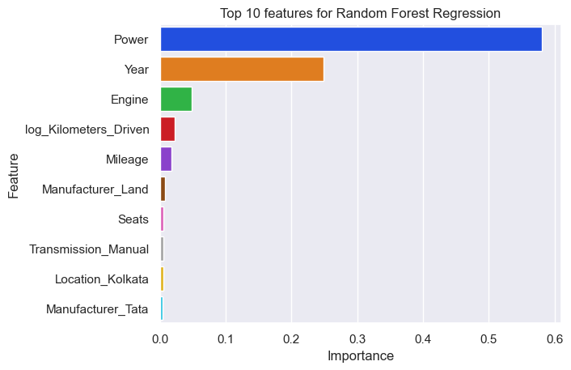

```python
# Create Tree Regression Importance Function for further use
def tree_regression_importance(model, X_train, y_train, top_values, model_name):
    '''
    Description: This will output features of importance in a tree regression model.
    X_train: X_train dataset.
    y_train: y_train dataset.
    top_values: The top # of features of importance.
    model_name: The name of the tree regression model.
    '''

    # Create title for Chart
    title = 'Top ' + str(top_values) + ' features for '+ model_name
    # Fit model
    model.fit(X_train, y_train)

    # Create list to hold features values
    feature_list = []

    # Extract feature names and their importance
    for feature, importance in zip(X_train.columns, model.feature_importances_):
        temp = [feature, importance]
        feature_list.append(temp)

    # Create Pandas DataFrame
    importance_df= pd.DataFrame(feature_list, columns = ['Feature', 'Importance'])
    importance_df= importance_df.sort_values('Importance', ascending = False)
    display(importance_df)

    # Create Barchart
    sns.barplot(data=importance_df[0:top_values],
                x='Importance',
                y='Feature',
                orient='h')

    # Title for chart
    plt.title(title)

# Show Importance Information
tree_regression_importance(rf_model,                                # Best performing regression model
                           X_train=X_train1,                         # X_train data
                           y_train=y_train1,                         # y_train data
                           top_values=10,                           # Top # of features
                           model_name='Random Forest Regression')   # Name of Tree Regression model
```

**Model 1- Random Forest Feature Importance Observations**-

- We saw as in Random Forest Regression that power was the largest predictor when it come to price. This again could be because of the high correlation between Price and Power that we saw earlier in the heatmap.
- We can see that there is more importance on the manufacturers here in this model.
- Year still is the second most important predictor for both models through.